# hw5

Neha Maddali

11/10/2021

```r
library(ggplot2)
library(dplyr)
library(tidyverse)
library(stringr)
library(lubridate) # Time
library(scales)
```

## Question 1

The complete dataset is too large. Download and import the alcohol sales data for Ames only:

```r
data <- read.csv('./2021_Iowa_Liquor_Sales.csv')
str(data)
```

```
## 'data.frame':    53456 obs. of  24 variables:
##  $ Invoice.Item.Number  : chr  "INV-33241300055" "INV-33266000034" "INV-33659200016" "INV-33241100134" ...
##  $ Date                 : chr  "01/06/2021" "01/07/2021" "01/21/2021" "01/06/2021" ...
##  $ Store.Number         : int  2501 5465 5465 2500 4129 4004 5927 3524 4509 4129 ...
##  $ Store.Name           : chr  "Hy-Vee  #2 / Ames" "Kum & Go #1215 / Ames" "Kum & Go #1215 / Ames" "Hy-Vee Food Store #1 / Ames" ...
##  $ Address              : chr  "640 Lincolnway" "4506 Lincoln Way" "4506 Lincoln Way" "3800 W Lincoln Way" ...
##  $ City                 : chr  "Ames" "Ames" "Ames" "Ames" ...
##  $ Zip.Code             : int  50010 50010 50010 50010 50010 50010 50010 50010 50010 50010 ...
##  $ Store.Location       : chr  "" "" "" "" ...
##  $ County.Number        : int  85 85 85 85 85 85 85 85 85 85 ...
##  $ County               : chr  "STORY" "STORY" "STORY" "STORY" ...
##  $ Category             : int  1032100 1062400 1062200 1081100 1091100 1071100 1041100 1011200 1031200 1032200 ...
##  $ Category.Name        : chr  "Imported Vodkas" "Spiced Rum" "White Rum" "Coffee Liqueurs" ...
##  $ Vendor.Number        : int  434 260 35 370 116 395 370 125 521 277 ...
##  $ Vendor.Name          : chr  "LUXCO INC" "DIAGEO AMERICAS" "BACARDI USA INC" "PERNOD RICARD USA" ...
##  $ Item.Number          : int  34546 43334 43121 67527 74829 58838 32236 17206 39706 34871 ...
##  $ Item.Description     : chr  "Pearl" "Captain Morgan Original Spiced" "Bacardi Superior Mini" "Kahlua Coffee" ...
##  $ Pack                 : int  12 24 12 12 6 6 12 6 6 12 ...
##  $ Bottle.Volume..ml.   : int  750 375 50 1000 750 1750 750 750 50 1000 ...
##  $ State.Bottle.Cost    : num  7 5 5.54 15.99 19.5 ...
##  $ State.Bottle.Retail  : num  10.5 7.5 8.31 23.99 29.25 ...
##  $ Bottles.Sold         : int  4 12 2 12 2 12 12 24 1 2 ...
##  $ Sale..Dollars.       : num  42 90 16.6 287.9 58.5 ...
##  $ Volume.Sold..Liters. : num  3 4.5 0.1 12 1.5 21 9 18 0.05 2 ...
##  $ Volume.Sold..Gallons.: num  0.79 1.18 0.02 3.17 0.39 5.54 2.37 4.75 0.01 0.52 ...
```

```r
new_data <- data
```

## Question 2

2a. Convert the Date column into a date object

```r
new_data <- new_data %>% mutate(Date = mdy(Date))
str(new_data)
```

```
## 'data.frame':    53456 obs. of  24 variables:
##  $ Invoice.Item.Number  : chr  "INV-33241300055" "INV-33266000034" "INV-33659200016" "INV-33241100134" ...
##  $ Date                 : Date, format: "2021-01-06" "2021-01-07" ...
##  $ Store.Number         : int  2501 5465 5465 2500 4129 4004 5927 3524 4509 4129 ...
##  $ Store.Name           : chr  "Hy-Vee  #2 / Ames" "Kum & Go #1215 / Ames" "Kum & Go #1215 / Ames" "Hy-Vee Food Store #1 / Ames" ...
##  $ Address              : chr  "640 Lincolnway" "4506 Lincoln Way" "4506 Lincoln Way" "3800 W Lincoln Way" ...
##  $ City                 : chr  "Ames" "Ames" "Ames" "Ames" ...
##  $ Zip.Code             : int  50010 50010 50010 50010 50010 50010 50010 50010 50010 50010 ...
##  $ Store.Location       : chr  "" "" "" "" ...
##  $ County.Number        : int  85 85 85 85 85 85 85 85 85 85 ...
##  $ County               : chr  "STORY" "STORY" "STORY" "STORY" ...
##  $ Category             : int  1032100 1062400 1062200 1081100 1091100 1071100 1041100 1011200 1031200 1032200 ...
##  $ Category.Name        : chr  "Imported Vodkas" "Spiced Rum" "White Rum" "Coffee Liqueurs" ...
##  $ Vendor.Number        : int  434 260 35 370 116 395 370 125 521 277 ...
##  $ Vendor.Name          : chr  "LUXCO INC" "DIAGEO AMERICAS" "BACARDI USA INC" "PERNOD RICARD USA" ...
##  $ Item.Number          : int  34546 43334 43121 67527 74829 58838 32236 17206 39706 34871 ...
##  $ Item.Description     : chr  "Pearl" "Captain Morgan Original Spiced" "Bacardi Superior Mini" "Kahlua Coffee" ...
##  $ Pack                 : int  12 24 12 12 6 6 12 6 6 12 ...
##  $ Bottle.Volume..ml.   : int  750 375 50 1000 750 1750 750 750 50 1000 ...
##  $ State.Bottle.Cost    : num  7 5 5.54 15.99 19.5 ...
##  $ State.Bottle.Retail  : num  10.5 7.5 8.31 23.99 29.25 ...
##  $ Bottles.Sold         : int  4 12 2 12 2 12 12 24 1 2 ...
##  $ Sale..Dollars.       : num  42 90 16.6 287.9 58.5 ...
##  $ Volume.Sold..Liters. : num  3 4.5 0.1 12 1.5 21 9 18 0.05 2 ...
##  $ Volume.Sold..Gallons.: num  0.79 1.18 0.02 3.17 0.39 5.54 2.37 4.75 0.01 0.52 ...
```

2b. Extract the longitude and latitude from the Store Location column, creating two new columns

```r
new_data <- separate(new_data, col = "Store.Location",
                     into=c("Point","Latitude","Longitude"),sep="\\(")
new_data$Point <- NULL
new_data <- separate(new_data, col="Latitude", into=c("Latitude","Longitude"),sep="\\)")
new_data <- separate(new_data, col="Latitude", into=c("Latitude","Longitude"),sep=" ")
str(new_data)
```

```
## 'data.frame':    53456 obs. of  25 variables:
##  $ Invoice.Item.Number  : chr  "INV-33241300055" "INV-33266000034" "INV-33659200016" "INV-33241100134" ...
##  $ Date                 : Date, format: "2021-01-06" "2021-01-07" ...
##  $ Store.Number         : int  2501 5465 5465 2500 4129 4004 5927 3524 4509 4129 ...
##  $ Store.Name           : chr  "Hy-Vee  #2 / Ames" "Kum & Go #1215 / Ames" "Kum & Go #1215 / Ames" "Hy-Vee Food Store #1 / Ames" ...
##  $ Address              : chr  "640 Lincolnway" "4506 Lincoln Way" "4506 Lincoln Way" "3800 W Lincoln Way" ...
##  $ City                 : chr  "Ames" "Ames" "Ames" "Ames" ...
##  $ Zip.Code             : int  50010 50010 50010 50010 50010 50010 50010 50010 50010 50010 ...
##  $ Latitude             : chr  NA NA NA NA ...
##  $ Longitude            : chr  NA NA NA NA ...
##  $ County.Number        : int  85 85 85 85 85 85 85 85 85 85 ...
##  $ County               : chr  "STORY" "STORY" "STORY" "STORY" ...
##  $ Category             : int  1032100 1062400 1062200 1081100 1091100 1071100 1041100 1011200 1031200 1032200 ...
##  $ Category.Name        : chr  "Imported Vodkas" "Spiced Rum" "White Rum" "Coffee Liqueurs" ...
##  $ Vendor.Number        : int  434 260 35 370 116 395 370 125 521 277 ...
##  $ Vendor.Name          : chr  "LUXCO INC" "DIAGEO AMERICAS" "BACARDI USA INC" "PERNOD RICARD USA" ...
##  $ Item.Number          : int  34546 43334 43121 67527 74829 58838 32236 17206 39706 34871 ...
##  $ Item.Description     : chr  "Pearl" "Captain Morgan Original Spiced" "Bacardi Superior Mini" "Kahlua Coffee" ...
##  $ Pack                 : int  12 24 12 12 6 6 12 6 6 12 ...
##  $ Bottle.Volume..ml.   : int  750 375 50 1000 750 1750 750 750 50 1000 ...
##  $ State.Bottle.Cost    : num  7 5 5.54 15.99 19.5 ...
##  $ State.Bottle.Retail  : num  10.5 7.5 8.31 23.99 29.25 ...
##  $ Bottles.Sold         : int  4 12 2 12 2 12 12 24 1 2 ...
##  $ Sale..Dollars.       : num  42 90 16.6 287.9 58.5 ...
##  $ Volume.Sold..Liters. : num  3 4.5 0.1 12 1.5 21 9 18 0.05 2 ...
##  $ Volume.Sold..Gallons.: num  0.79 1.18 0.02 3.17 0.39 5.54 2.37 4.75 0.01 0.52 ...
```

## Question 3

First overview: Provide a visual breakdown of the liquor category (by Category Name). Include volume sold in the breakdown. Describe your figure. Which type of liquor is the most popular?

```r
new_data$`Category.Name` = factor(new_data$`Category.Name`)
temp_data <- new_data %>% arrange(desc(`Volume.Sold..Gallons.`))
head(temp_data)
```

```
##   Invoice.Item.Number       Date Store.Number             Store.Name
## 1     INV-39523800023 2021-08-25         3524 Sam's Club 6568 / Ames
## 2     INV-36353500001 2021-05-05         3524 Sam's Club 6568 / Ames
## 3     INV-40725900001 2021-10-06         3524 Sam's Club 6568 / Ames
## 4     INV-39523800024 2021-08-25         3524 Sam's Club 6568 / Ames
## 5     INV-37550500008 2021-06-16         3524 Sam's Club 6568 / Ames
## 6     INV-34901900001 2021-03-10         3524 Sam's Club 6568 / Ames
##          Address City Zip.Code   Latitude Longitude County.Number County
## 1 305 Airport Rd Ames    50010 -93.613648 42.001123            85  STORY
## 2 305 Airport Rd Ames    50010 -93.613648 42.001123            85  STORY
## 3 305 Airport Rd Ames    50010 -93.613648 42.001123            85  STORY
## 4 305 Airport Rd Ames    50010 -93.613648 42.001123            85  STORY
## 5 305 Airport Rd Ames    50010 -93.613648 42.001123            85  STORY
## 6 305 Airport Rd Ames    50010 -93.613648 42.001123            85  STORY
##   Category                       Category.Name Vendor.Number
```

[output cut: 27 more lines]

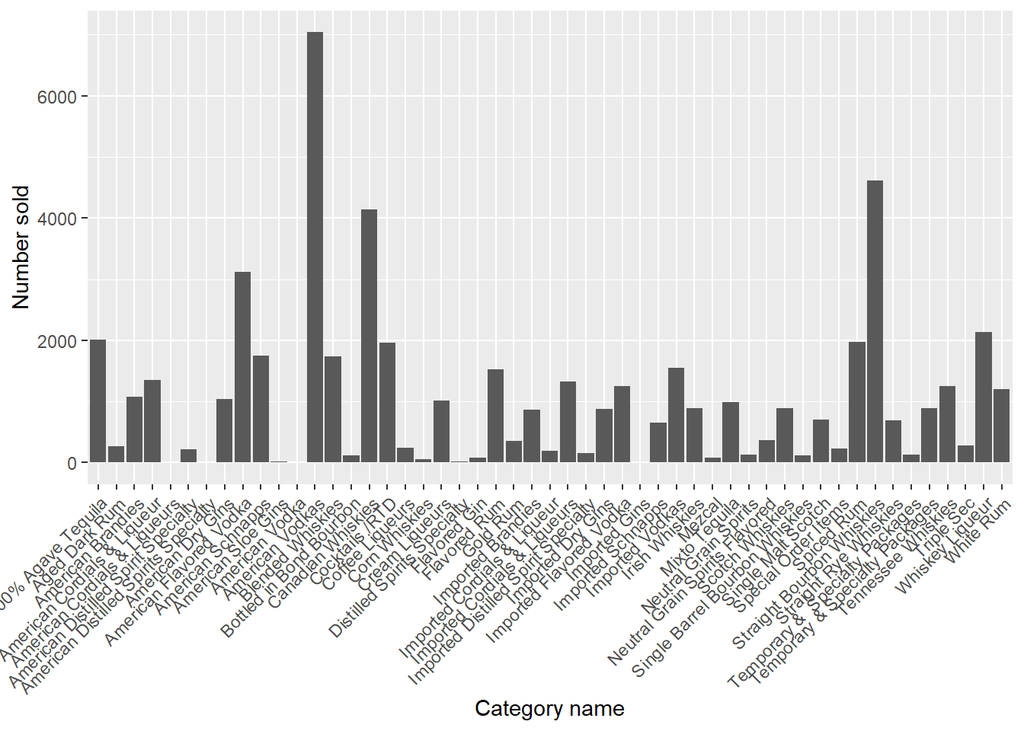

```r
labels = temp_data$`Category.Name`[1:20]

new_data %>% ggplot(aes(x = `Category.Name`), group_by = `Volume.Sold..Gallons.`) +
  geom_bar() +
  #scale_x_discrete(breaks = labels) +
  theme(axis.text.x = element_text(angle = 45, hjust = 1)) +
  labs(x = "Category name", y = "Number sold")
```

ANALYSIS: American Vodkas is the most popular as it has the most number sold compared to the other categories.

## Question 4

Which day of the week has the most orders? Use a barchart to visualize the results. Explain the pattern and provide a reason why the pattern occurs.

```r
data1 <- new_data
data1$weekday <- weekdays(data1$Date)
str(data1)
```

```
## 'data.frame':    53456 obs. of  26 variables:
##  $ Invoice.Item.Number  : chr  "INV-33241300055" "INV-33266000034" "INV-33659200016" "INV-33241100134" ...
##  $ Date                 : Date, format: "2021-01-06" "2021-01-07" ...
##  $ Store.Number         : int  2501 5465 5465 2500 4129 4004 5927 3524 4509 4129 ...
##  $ Store.Name           : chr  "Hy-Vee  #2 / Ames" "Kum & Go #1215 / Ames" "Kum & Go #1215 / Ames" "Hy-Vee Food Store #1 / Ames" ...
##  $ Address              : chr  "640 Lincolnway" "4506 Lincoln Way" "4506 Lincoln Way" "3800 W Lincoln Way" ...
##  $ City                 : chr  "Ames" "Ames" "Ames" "Ames" ...
##  $ Zip.Code             : int  50010 50010 50010 50010 50010 50010 50010 50010 50010 50010 ...
##  $ Latitude             : chr  NA NA NA NA ...
##  $ Longitude            : chr  NA NA NA NA ...
##  $ County.Number        : int  85 85 85 85 85 85 85 85 85 85 ...
##  $ County               : chr  "STORY" "STORY" "STORY" "STORY" ...
##  $ Category             : int  1032100 1062400 1062200 1081100 1091100 1071100 1041100 1011200 1031200 1032200 ...
##  $ Category.Name        : Factor w/ 51 levels "100% Agave Tequila",..: 33 43 51 18 6 17 8 44 9 30 ...
##  $ Vendor.Number        : int  434 260 35 370 116 395 370 125 521 277 ...
##  $ Vendor.Name          : chr  "LUXCO INC" "DIAGEO AMERICAS" "BACARDI USA INC" "PERNOD RICARD USA" ...
##  $ Item.Number          : int  34546 43334 43121 67527 74829 58838 32236 17206 39706 34871 ...
##  $ Item.Description     : chr  "Pearl" "Captain Morgan Original Spiced" "Bacardi Superior Mini" "Kahlua Coffee" ...
##  $ Pack                 : int  12 24 12 12 6 6 12 6 6 12 ...
##  $ Bottle.Volume..ml.   : int  750 375 50 1000 750 1750 750 750 50 1000 ...
##  $ State.Bottle.Cost    : num  7 5 5.54 15.99 19.5 ...
##  $ State.Bottle.Retail  : num  10.5 7.5 8.31 23.99 29.25 ...
##  $ Bottles.Sold         : int  4 12 2 12 2 12 12 24 1 2 ...
##  $ Sale..Dollars.       : num  42 90 16.6 287.9 58.5 ...
##  $ Volume.Sold..Liters. : num  3 4.5 0.1 12 1.5 21 9 18 0.05 2 ...
##  $ Volume.Sold..Gallons.: num  0.79 1.18 0.02 3.17 0.39 5.54 2.37 4.75 0.01 0.52 ...
##  $ weekday              : chr  "Wednesday" "Thursday" "Thursday" "Wednesday" ...
```

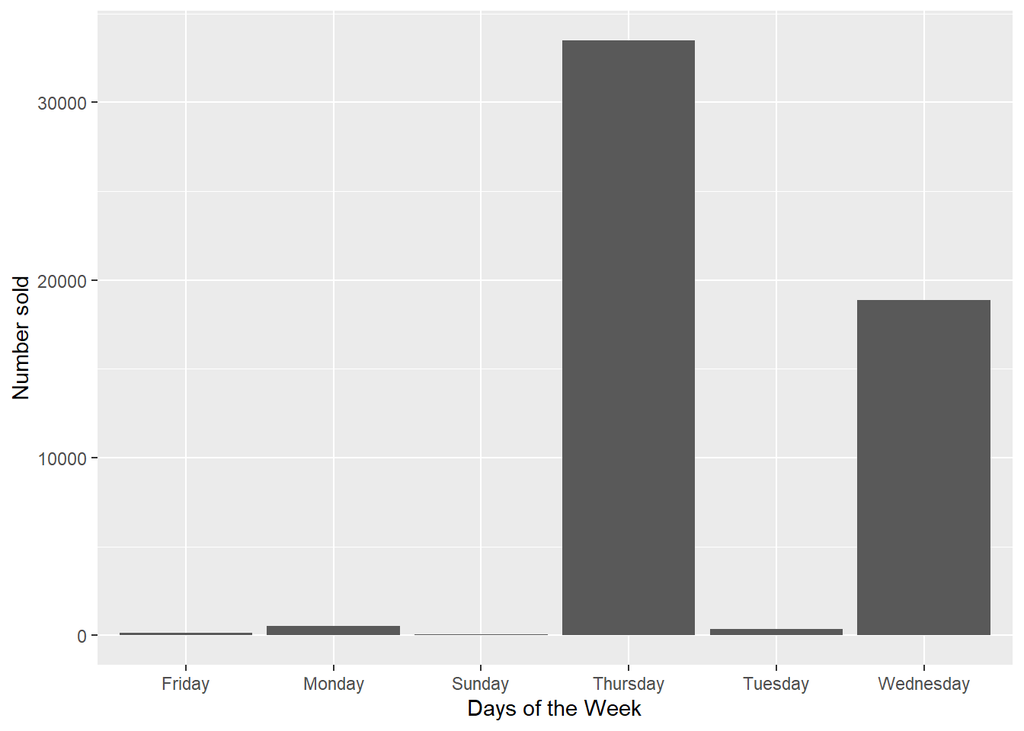

```r
data1 %>% ggplot(aes(x = weekday), group_by = `Volume.Sold..Gallons.`) +
  geom_bar() +
  labs(x = "Days of the Week", y = "Number sold")
```

ANALYSIS: Thursdays have the most orders. This could be a preparation for the weekend type of parties that occur.

## Question 5

Create a single plot for the monthly volumes sold. Each liquor category should be shown using a separate time series. Label the top 5 categories using text labels.

```r
monthly <- new_data %>%
  group_by(Name=`Category.Name`, month=floor_date(new_data$Date, "month")) %>%
  summarize(totalVolumes = sum(`Volume.Sold..Gallons.`), Name, month)
```

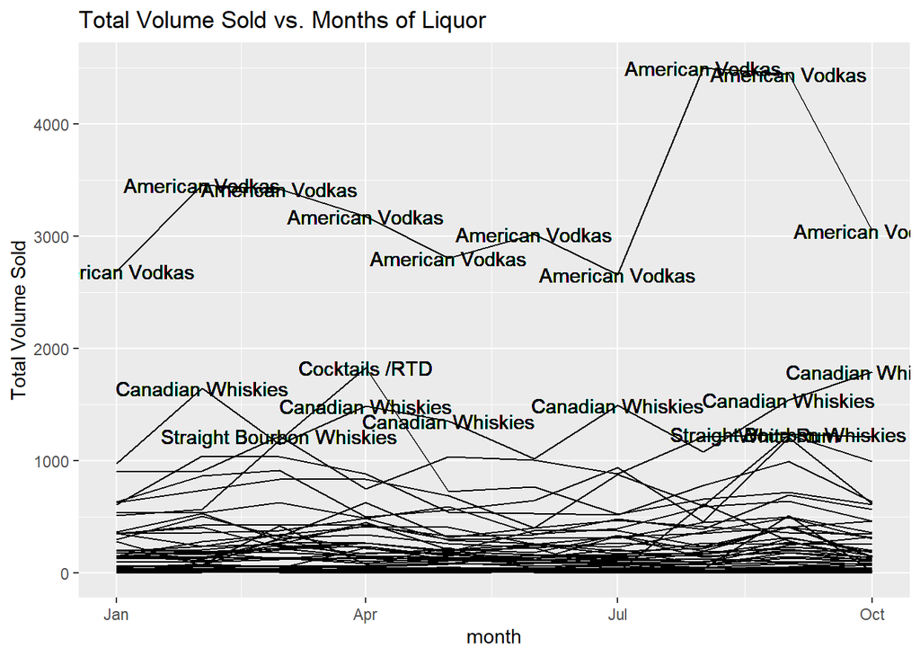

```r
monthlySummary <- monthly %>%
  group_by(Name) %>%
  summarize(month=max(month), totalVolumes = max(totalVolumes))
monthlySummary <- monthlySummary %>%
  arrange(desc(totalVolumes))

ggplot(monthly, aes(x=month, y=totalVolumes, by=Name))+geom_line() +
  labs(y="Total Volume Sold", title="Total Volume Sold vs. Months of Liquor") +
  geom_text(aes(x=month, y=totalVolumes, label=Name),data=monthly %>% filter(totalVolumes > 1210))
```

ANALYSIS: American Vodkas are the highest in volumes sold (gallons) per month. The top 5 categories are American Vodkas, Canadian Whiskies, Cocktails/RTD, Straight Bourbon Whiskies, and White Rum.

## Question 6

Which categories are spring graduation party favorites? Find at least one category.

```r
datTest <- new_data %>%
  select(Date, Volume.Sold..Gallons.,Category.Name,) %>%
  filter(between(Date, as.Date("2021-04-01"), as.Date("2021-06-30"))) %>%
  group_by(Name=`Category.Name`) %>%
  summarize(totalVolumes = sum(`Volume.Sold..Gallons.`)) %>%
  arrange(desc(totalVolumes))
str(datTest)
```

```
## tibble [50 x 2] (S3: tbl_df/tbl/data.frame)
##  $ Name        : Factor w/ 51 levels "100% Agave Tequila",..: 13 16 17 44 9 51 43 23 33 50 ...
##  $ totalVolumes: num [1:50] 8992 3850 3314 2789 1947 ...
```

ANALYSIS: For this problem, I looked at the volume sold in gallons for the months of April, May, and June. American Vodkas is the highest category. The second and third are Canadian Whiskies, Cocktails/RTD. These can be the spring graduation party favorites.